# CI_Ex2_KP

Kyuri Park 5439043

3/8/2022

## 1. Data and R-pacakges

```r
# load data
df <- read.table("SchaferKangData.dat", header=T)
df[1:10,]
```

```
##    DISTR.1 BLACK NBHISP GRADE SLFHLTH SLFWGHT WORKHARD GOODQUAL PHYSFIT PROUD
## 1     0.47     0      0    10       4       4        2        2       2     2
## 2     0.05     0      0     8       2       3        1        1       2     1
## 3     0.63     0      0     8       2       3        2        2       2     2
## 4     0.16     1      0     9       1       4        2        1       2     1
## 5     1.79     1      0     9       4       4        1        2       2     2
## 6     0.32     0      0    10       1       3        1        1       2     1
## 7     1.11     0      0    10       2       3        1        1       2     1
## 8     0.32     0      0     9       3       4        2        1       3     2
## 9     0.26     0      0    10       1       4        2        2       2     2
## 10    0.89     1      0    10       2       2        2        2       1     1
##    LIKESLF ACCEPTED FEELLOVD DIET DISTR.2
## 1        5        2        2    1    0.40
## 2        1        2        1    1    0.09
## 3        3        2        2    0    0.69
## 4        2        2        1    1    0.08
## 5        3        3        2    0    1.41
## 6        4        1        1    0    0.52
## 7        2        2        2    0    1.32
## 8        2        3        3    0    0.29
## 9        1        3        2    0    0.43
## 10       1        1        1    0    1.76
```

## 2. Prima Facie Effect : Not controlling for any variable

### 2.1 Method1: Compare Means

▸ Compare the means between the groups on the outcome variable (see Equation (5) in S&K; use for instance t.test() in R).

The mean difference is the “prima facie” estimate of the average causal effect of dieting on distress. The results indicate that the average of the girls who did diet is (0.703-0.645=)0.059 higher than the average of the girls who did not diet ($SE=0.015$). This difference is statistically significant.

```r
t.test1 <- t.test(DISTR.2 ~ DIET, df)
# Difference in means between the groups:
m1 <- t.test1$estimate[[2]]
m0 <- t.test1$estimate[[1]]

# mean difference
m1 - m0
```

```
## [1] 0.05961424
```

```r
# std. error
t.test1$stderr
```

```
## [1] 0.01533978
```

```r
# p-value
t.test1$p.value
```

```
## [1] 0.0001054363
```

### 2.2 Invetigating covariates - potential confounding

▸ Determine the standardized mean difference between the girls who did diet versus the girls who did not diet on the first covariate, that is: DISTR.1 (emotional distress at wave 1).

```r
df1 <- df[ which(df$DIET == 1), ]
df0 <- df[ which(df$DIET == 0), ]

(mean(df1$DISTR.1) - mean(df0$DISTR.1))/(sqrt( (var(df1$DISTR.1)+var(df0$DISTR.1))/2 ))
```

```
## [1] 0.2142174
```

▸ Instead of computing these standardized mean differences yourself, you can also use the function CreateTableOne() from the package tableone. Run the code below.

```r
library(tableone)
table1 <- CreateTableOne(vars=c("DISTR.1","BLACK", "NBHISP", "GRADE",
                      "SLFHLTH", "SLFWGHT", "WORKHARD", "GOODQUAL",
                          "PHYSFIT", "PROUD", "LIKESLF", "ACCEPTED",
                      "FEELLOVD"), strata="DIET", data=df,
                        test=FALSE)
```

▸ Obtain the table with standardize mean differences using print(table1, smd=TRUE), and comment on the results.

Most of the standardized mean difference are larger than the rule o thumb (0.1). This implies that for multiple covariates, the difference between their means of the two treatment groups are larger than 0.1 standard deviations. This indicates considerable imbalance across the two groups with respect to these covariates. This means the data do not mimic RCT very well.  
Hence, we need to take some actions to takle this.

```r
print(table1, smd=TRUE)
```

```
##                       Stratified by DIET
##                        0           1           SMD
##   n                    4780        1220
##   DISTR.1 (mean (SD))  0.62 (0.42) 0.71 (0.45)  0.214
##   BLACK (mean (SD))    0.26 (0.44) 0.17 (0.38)  0.197
##   NBHISP (mean (SD))   0.15 (0.35) 0.15 (0.36)  0.021
##   GRADE (mean (SD))    9.16 (1.39) 9.37 (1.34)  0.152
##   SLFHLTH (mean (SD))  2.20 (0.93) 2.35 (0.91)  0.171
##   SLFWGHT (mean (SD))  3.19 (0.76) 3.84 (0.70)  0.895
##   WORKHARD (mean (SD)) 2.14 (0.91) 2.05 (0.85)  0.093
##   GOODQUAL (mean (SD)) 1.80 (0.67) 1.84 (0.71)  0.055
##   PHYSFIT (mean (SD))  2.24 (0.93) 2.53 (0.93)  0.320
##   PROUD (mean (SD))    1.76 (0.77) 1.86 (0.79)  0.126
##   LIKESLF (mean (SD))  2.09 (0.99) 2.52 (1.06)  0.420
##   ACCEPTED (mean (SD)) 2.14 (1.00) 2.35 (1.06)  0.207
##   FEELLOVD (mean (SD)) 1.78 (0.83) 1.93 (0.90)  0.172
```

## 3. Controlling for Confounders Z: Model the relation of Z with Y

### 3.1 Metohd 1: ANCOVA (Linear Regression without Interactions)

The result below show that after correcting for the effect of the covariates, the effect of the treatment (DIET) on the outcome (DISTR.2) is not significant. The estimate of the ACE is -0.014 (SE = 0.013).

```r
M2 <- glm(DISTR.2 ~ ., data=df)
summary(M2)
```

```
##
## Call:
## glm(formula = DISTR.2 ~ ., data = df)
##
## Deviance Residuals:
##      Min        1Q    Median        3Q       Max
## -1.69102  -0.22781  -0.05734   0.18025   1.81213
##
## Coefficients:
##               Estimate Std. Error t value Pr(>|t|)
## (Intercept) -0.0052087  0.0422214  -0.123 0.901821
## DISTR.1      0.5178247  0.0125785  41.168  < 2e-16 ***
## BLACK        0.0745764  0.0120532   6.187 6.53e-10 ***
## NBHISP       0.0289905  0.0141752   2.045 0.040884 *
## GRADE        0.0019352  0.0035672   0.543 0.587490
## SLFHLTH      0.0196974  0.0059809   3.293 0.000996 ***
## SLFWGHT      0.0038613  0.0069990   0.552 0.581183
## WORKHARD    -0.0121711  0.0056656  -2.148 0.031734 *
## GOODQUAL     0.0209810  0.0098513   2.130 0.033231 *
## PHYSFIT     -0.0005642  0.0069283  -0.081 0.935099
## PROUD        0.0376379  0.0101757   3.699 0.000219 ***
## LIKESLF      0.0242944  0.0064040   3.794 0.000150 ***
## ACCEPTED     0.0167152  0.0068032   2.457 0.014040 *
## FEELLOVD     0.0389178  0.0085254   4.565 5.10e-06 ***
## DIET        -0.0136658  0.0129321  -1.057 0.290675
## ---
## Signif. codes:  0 '***' 0.001 '**' 0.01 '*' 0.05 '.' 0.1 ' ' 1
##
## (Dispersion parameter for gaussian family taken to be 0.1412421)
##
##     Null deviance: 1303.09  on 5999  degrees of freedom
## Residual deviance:  845.33  on 5985  degrees of freedom
## AIC: 5300.6
##
## Number of Fisher Scoring iterations: 2
```

```r
#summary(lm(DISTR.2 ~ ., data=df)) # same as lm() right? here, yes.
```

### 3.2 Method 2: Regression (Linear Regression with extras such as interactions)

▸ Run the regression model with two-way interactions between the treatment variable and the covariates, for instance using the function glm() in R, and interpret the results.

We need to center the covariates first, to make sure the main effect interpretation of treatment can be: the casual effect when the other variables take on their mean value (0) –> average causal effect

```r
##### center the covariates #####
covariates <- colnames(df[1:13])
centered_df <- df %>%
  mutate_at(covariates, scale, scale = FALSE)  # center but no scale.

# Model with two-way interactions
M2b <- glm(DISTR.2 ~ . + DIET:. , data= centered_df)
summary(M2b)
```

```
##
## Call:
## glm(formula = DISTR.2 ~ . + DIET:., data = centered_df)
##
## Deviance Residuals:
##      Min        1Q    Median        3Q       Max
## -1.72288  -0.22801  -0.05723   0.18175   1.82660
##
## Coefficients:
##                 Estimate Std. Error t value Pr(>|t|)
## (Intercept)    0.6587668  0.0055344 119.031  < 2e-16 ***
## DISTR.1        0.5210525  0.0143816  36.230  < 2e-16 ***
## BLACK          0.0742012  0.0131869   5.627 1.92e-08 ***
## NBHISP         0.0241334  0.0159814   1.510 0.131071
## GRADE          0.0021585  0.0039652   0.544 0.586210
## SLFHLTH        0.0257745  0.0067034   3.845 0.000122 ***
## SLFWGHT        0.0026900  0.0077575   0.347 0.728781
## WORKHARD      -0.0194426  0.0062698  -3.101 0.001938 **
## GOODQUAL       0.0154691  0.0110400   1.401 0.161212
## PHYSFIT        0.0054135  0.0077812   0.696 0.486635
## PROUD          0.0329261  0.0113575   2.899 0.003756 **
## LIKESLF        0.0225898  0.0072863   3.100 0.001942 **
## ACCEPTED       0.0159821  0.0077195   2.070 0.038462 *
## FEELLOVD       0.0412613  0.0095958   4.300 1.74e-05 ***
## DIET          -0.0058574  0.0149019  -0.393 0.694286
## DISTR.1:DIET  -0.0106838  0.0296963  -0.360 0.719033
## BLACK:DIET    -0.0003361  0.0327604  -0.010 0.991814
## NBHISP:DIET    0.0238344  0.0346707   0.687 0.491826
## GRADE:DIET     0.0023927  0.0091386   0.262 0.793465
## SLFHLTH:DIET  -0.0297672  0.0150042  -1.984 0.047310 *
## SLFWGHT:DIET  -0.0011506  0.0181310  -0.063 0.949404
## WORKHARD:DIET  0.0392602  0.0147076   2.669 0.007620 **
## GOODQUAL:DIET  0.0260125  0.0246058   1.057 0.290477
## PHYSFIT:DIET  -0.0266321  0.0171818  -1.550 0.121190
## PROUD:DIET     0.0240841  0.0255893   0.941 0.346650
## LIKESLF:DIET   0.0086665  0.0153017   0.566 0.571161
## ACCEPTED:DIET -0.0015125  0.0164325  -0.092 0.926664
## FEELLOVD:DIET -0.0125126  0.0209234  -0.598 0.549850
## ---
## Signif. codes:  0 '***' 0.001 '**' 0.01 '*' 0.05 '.' 0.1 ' ' 1
##
## (Dispersion parameter for gaussian family taken to be 0.1410809)
##
##     Null deviance: 1303.09  on 5999  degrees of freedom
## Residual deviance:  842.54  on 5972  degrees of freedom
## AIC: 5306.7
##
## Number of Fisher Scoring iterations: 2
```

### 3.3 Method 3: Regression estimation

▸ Start with creating separate data sets for the two treatment groups, and running a regression analysis for each group separately:

```r
groups <- df %>%  group_split(DIET)
names(groups) <- c("DIET0", "DIET1")

# Regression analysis with only people with X=0:
M3.0 <- glm(DISTR.2 ~., data=groups[[1]])
summary(M3.0)
```

```
##
## Call:
## glm(formula = DISTR.2 ~ ., data = groups[[1]])
##
## Deviance Residuals:
##      Min        1Q    Median        3Q       Max
## -1.52178  -0.22574  -0.06029   0.18152   1.82660
##
## Coefficients: (1 not defined because of singularities)
##              Estimate Std. Error t value Pr(>|t|)
## (Intercept)  0.003313   0.046154   0.072 0.942781
## DISTR.1      0.521052   0.014239  36.594  < 2e-16 ***
## BLACK        0.074201   0.013056   5.683 1.40e-08 ***
## NBHISP       0.024133   0.015823   1.525 0.127267
## GRADE        0.002159   0.003926   0.550 0.582467
## SLFHLTH      0.025775   0.006637   3.884 0.000104 ***
## SLFWGHT      0.002690   0.007681   0.350 0.726175
## WORKHARD    -0.019443   0.006208  -3.132 0.001746 **
## GOODQUAL     0.015469   0.010930   1.415 0.157068
## PHYSFIT      0.005414   0.007704   0.703 0.482285
## PROUD        0.032926   0.011245   2.928 0.003426 **
## LIKESLF      0.022590   0.007214   3.131 0.001750 **
## ACCEPTED     0.015982   0.007643   2.091 0.036571 *
## FEELLOVD     0.041261   0.009501   4.343 1.43e-05 ***
## DIET               NA         NA      NA       NA
## ---
## Signif. codes:  0 '***' 0.001 '**' 0.01 '*' 0.05 '.' 0.1 ' ' 1
##
## (Dispersion parameter for gaussian family taken to be 0.138295)
##
##     Null deviance: 1015.82  on 4779  degrees of freedom
## Residual deviance:  659.11  on 4766  degrees of freedom
## AIC: 4124.4
##
## Number of Fisher Scoring iterations: 2
```

```r
# Regression analysis with only people with X=1:
M3.1 <- glm(DISTR.2 ~., data=groups[[2]])
summary(M3.1)
```

```
##
## Call:
## glm(formula = DISTR.2 ~ ., data = groups[[2]])
##
## Deviance Residuals:
##      Min        1Q    Median        3Q       Max
## -1.72288  -0.23844  -0.04559   0.18345   1.80501
##
## Coefficients: (1 not defined because of singularities)
##              Estimate Std. Error t value Pr(>|t|)
## (Intercept) -0.056083   0.109622  -0.512   0.6090
## DISTR.1      0.510369   0.026976  18.919   <2e-16 ***
## BLACK        0.073865   0.031137   2.372   0.0178 *
## NBHISP       0.047968   0.031946   1.502   0.1335
## GRADE        0.004551   0.008549   0.532   0.5946
## SLFHLTH     -0.003993   0.013937  -0.286   0.7746
## SLFWGHT      0.001539   0.017015   0.090   0.9279
## WORKHARD     0.019818   0.013814   1.435   0.1516
## GOODQUAL     0.041482   0.022832   1.817   0.0695 .
## PHYSFIT     -0.021219   0.015905  -1.334   0.1824
## PROUD        0.057010   0.023809   2.395   0.0168 *
## LIKESLF      0.031256   0.013971   2.237   0.0255 *
## ACCEPTED     0.014470   0.015062   0.961   0.3369
## FEELLOVD     0.028749   0.019305   1.489   0.1367
## DIET               NA         NA      NA       NA
## ---
## Signif. codes:  0 '***' 0.001 '**' 0.01 '*' 0.05 '.' 0.1 ' ' 1
##
## (Dispersion parameter for gaussian family taken to be 0.1520904)
##
##     Null deviance: 283.81  on 1219  degrees of freedom
## Residual deviance: 183.42  on 1206  degrees of freedom
## AIC: 1180.5
##
## Number of Fisher Scoring iterations: 2
```

▸ Now, obtain estimates for everyone (both for those who we observed X=1 and X=0) for the potential outcome under treatment and under no treatment:

```r
# Obtain a prediction for the outcome using all the cases, based on
# the parameter estimates obtained above and saved in M3.1:
M3.est.Y1 <- predict(M3.1, newdata = df)
# Do the same, but now with the parameters saved in M3.0:
M3.est.Y0 <- predict(M3.0, newdata = df)
```

▸ Estimate the average causal effect based on what you have created in the previous (focus on obtaining the point estimate, you do not need to obtain a correct standard error/certainty interval/p-value).

```r
# Look at the predicted potential outcomes
cbind(M3.est.Y0, M3.est.Y1)[1:10,]
```

```
##    M3.est.Y0 M3.est.Y1
## 1  0.6798196 0.6563903
## 2  0.2418481 0.1672951
## 3  0.6594521 0.6728799
## 4  0.3555863 0.3584581
## 5  1.4298966 1.3315301
## 6  0.4128621 0.3974892
## 7  0.8623319 0.7773935
## 8  0.5531470 0.4660255
## 9  0.4186977 0.4506349
## 10 0.7299912 0.7454811
```

```r
# Estimate the causal effect now, using a t-test
t.test(M3.est.Y0, M3.est.Y1, paired = TRUE, alternative = "two.sided") #paried = TRUE!
```

```
##
##  Paired t-test
##
## data:  M3.est.Y0 and M3.est.Y1
## t = 8.2764, df = 5999, p-value < 2.2e-16
## alternative hypothesis: true difference in means is not equal to 0
## 95 percent confidence interval:
##  0.004470006 0.007244792
## sample estimates:
## mean of the differences
##             0.005857399
```

▸ (OPTIONAL) Above we have used the predicted potential outcomes for everyone. However, one of them is actually observed, and we could use those instead of the predicted potential outcome (i.e., we use the observed fact, and predict only the counterfact). Check whether this leads to a different result.  
Yes, the p-value is not significant any longer.

```r
# Take the predicted potential outcome for X=0
# and only for those for whom we observed X=0
# do we overwrite the predicted potential outcome
M3b.Y0 <- M3.est.Y0
M3b.Y0[df$DIET==0] <- df$DISTR.2[df$DIET==0]

# Do the same for the predicted potential outcome for X=1
M3b.Y1 <- M3.est.Y1
M3b.Y1[df$DIET==1] <- df$DISTR.2[df$DIET==1]

# Now do the t-test with these (observed and predicted) potential outcomes:
t.test(M3b.Y0, M3b.Y1, paired = TRUE, alternative = "two.sided")
```

```
##
##  Paired t-test
##
## data:  M3b.Y0 and M3b.Y1
## t = 1.1979, df = 5999, p-value = 0.231
## alternative hypothesis: true difference in means is not equal to 0
## 95 percent confidence interval:
##  -0.003728044  0.015442842
## sample estimates:
## mean of the differences
##             0.005857399
```

### 3.4 Conclusion

▸ To get a first impression of whether this extrapolation issue applies here, use standardized mean differences again. In this case, use cut off of 0.3 to indicate a potential problem.

```r
library(resample) # for colVars

df1 <- df[ which(df$DIET == 1), ][1:13]
df0 <- df[ which(df$DIET == 0), ][1:13]
mean1 <- colMeans(df1)
mean0 <- colMeans(df0)
var1 <- colVars(df1)
var0 <- colVars(df0)
smd <- abs( (mean1- mean0) / sqrt((var1 + var0)/2) )
smd[smd > 0.3]
```

```
##   SLFWGHT   PHYSFIT   LIKESLF
## 0.8949423 0.3202104 0.4197258
```

```r
# OR using table1
table1 <- CreateTableOne(vars=c("DISTR.1","BLACK", "NBHISP", "GRADE",
                      "SLFHLTH", "SLFWGHT", "WORKHARD", "GOODQUAL",
                          "PHYSFIT", "PROUD", "LIKESLF", "ACCEPTED",
                      "FEELLOVD"), strata="DIET", data=df,
                        test=FALSE)
print(table1, smd =TRUE)
```

```
##                       Stratified by DIET
##                        0           1           SMD
##   n                    4780        1220
##   DISTR.1 (mean (SD))  0.62 (0.42) 0.71 (0.45)  0.214
##   BLACK (mean (SD))    0.26 (0.44) 0.17 (0.38)  0.197
##   NBHISP (mean (SD))   0.15 (0.35) 0.15 (0.36)  0.021
##   GRADE (mean (SD))    9.16 (1.39) 9.37 (1.34)  0.152
##   SLFHLTH (mean (SD))  2.20 (0.93) 2.35 (0.91)  0.171
##   SLFWGHT (mean (SD))  3.19 (0.76) 3.84 (0.70)  0.895
##   WORKHARD (mean (SD)) 2.14 (0.91) 2.05 (0.85)  0.093
##   GOODQUAL (mean (SD)) 1.80 (0.67) 1.84 (0.71)  0.055
##   PHYSFIT (mean (SD))  2.24 (0.93) 2.53 (0.93)  0.320
##   PROUD (mean (SD))    1.76 (0.77) 1.86 (0.79)  0.126
##   LIKESLF (mean (SD))  2.09 (0.99) 2.52 (1.06)  0.420
##   ACCEPTED (mean (SD)) 2.14 (1.00) 2.35 (1.06)  0.207
##   FEELLOVD (mean (SD)) 1.78 (0.83) 1.93 (0.90)  0.172
```

## 4. Controlling for Confounders Z: Model the relation of Z with X

### 4.1 Estimate the propensity scores

▸ To compute a propensity score, run a logistic regression model in which the treatment variable X (which has values 0 and 1) is the outcome variable, and the covariates are the predictors. Make sure to save the probability for each person for scoring 1 on X (here: DIET). You can use the glm function from the stats package for this.

```r
library(stats)

# Run the logistic regression analysis
logreg <- glm(DIET ~., family = binomial(), data = df[-15])
summary(logreg)
```

```
##
## Call:
## glm(formula = DIET ~ ., family = binomial(), data = df[-15])
##
## Deviance Residuals:
##     Min       1Q   Median       3Q      Max
## -1.8810  -0.6611  -0.4683  -0.2443   3.0816
##
## Coefficients:
##             Estimate Std. Error z value Pr(>|z|)
## (Intercept) -6.18454    0.33267 -18.591  < 2e-16 ***
## DISTR.1      0.32328    0.08609   3.755 0.000173 ***
## BLACK       -0.52714    0.09271  -5.686 1.30e-08 ***
## NBHISP      -0.17469    0.09938  -1.758 0.078785 .
## GRADE        0.09175    0.02599   3.530 0.000416 ***
## SLFHLTH     -0.04820    0.04235  -1.138 0.255035
## SLFWGHT      1.16795    0.05446  21.448  < 2e-16 ***
## WORKHARD    -0.13147    0.04133  -3.181 0.001468 **
## GOODQUAL    -0.19374    0.07105  -2.727 0.006395 **
## PHYSFIT      0.04328    0.04813   0.899 0.368585
## PROUD       -0.03753    0.07211  -0.520 0.602797
## LIKESLF      0.28300    0.04366   6.482 9.05e-11 ***
## ACCEPTED    -0.11514    0.04788  -2.405 0.016177 *
## FEELLOVD     0.04735    0.05961   0.794 0.427022
## ---
## Signif. codes:  0 '***' 0.001 '**' 0.01 '*' 0.05 '.' 0.1 ' ' 1
##
## (Dispersion parameter for binomial family taken to be 1)
##
##     Null deviance: 6059.9  on 5999  degrees of freedom
## Residual deviance: 5201.7  on 5986  degrees of freedom
## AIC: 5229.7
##
## Number of Fisher Scoring iterations: 5
```

```r
# Obtain a prediction of the probability of treatment (i.e., DIET=1)
ps <- predict(logreg, type = "response")

# Add this predicted probability to the data file
df$ps <- ps

# Look at the datafile
round(df[1:10,], 2)
```

```
##    DISTR.1 BLACK NBHISP GRADE SLFHLTH SLFWGHT WORKHARD GOODQUAL PHYSFIT PROUD
## 1     0.47     0      0    10       4       4        2        2       2     2
## 2     0.05     0      0     8       2       3        1        1       2     1
## 3     0.63     0      0     8       2       3        2        2       2     2
## 4     0.16     1      0     9       1       4        2        1       2     1
## 5     1.79     1      0     9       4       4        1        2       2     2
## 6     0.32     0      0    10       1       3        1        1       2     1
## 7     1.11     0      0    10       2       3        1        1       2     1
## 8     0.32     0      0     9       3       4        2        1       3     2
## 9     0.26     0      0    10       1       4        2        2       2     2
## 10    0.89     1      0    10       2       2        2        2       1     1
##    LIKESLF ACCEPTED FEELLOVD DIET DISTR.2   ps
## 1        5        2        2    1    0.40 0.50
## 2        1        2        1    1    0.09 0.10
## 3        3        2        2    0    0.69 0.15
## 4        2        2        1    1    0.08 0.23
## 5        3        3        2    0    1.41 0.32
## 6        4        1        1    0    0.52 0.28
## 7        2        2        2    0    1.32 0.21
## 8        2        3        3    0    0.29 0.32
## 9        1        3        2    0    0.43 0.24
## 10       1        1        1    0    1.76 0.02
```

▸ Make a plot that includes a histogram for the propensities of the treated, and a histogram for the propensity scores of the untreated to evaluate this. Discuss what you see in the plot, and what this may imply for our causal inferences.

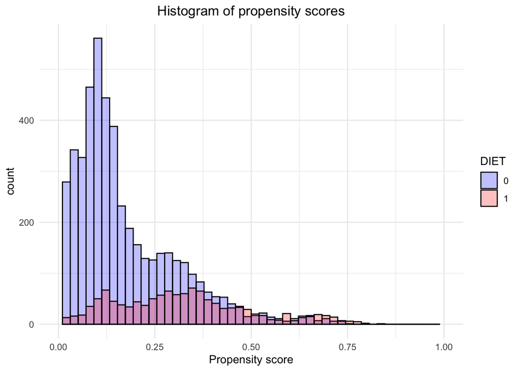

```r
library(ggplot2)

df %>%
  ggplot(aes(x=ps, fill=factor(DIET))) +
  geom_histogram(color="black", position="identity", bins=50) +
  scale_fill_manual(values=c(rgb(0,0,1,1/4), rgb(1,0,0,1/4)), name="DIET") +
  labs(title="Histogram of propensity scores", x = "Propensity score") + xlim(0,1) +
  theme_minimal()+
  theme(plot.title = element_text(hjust = 0.5))
```

### 4.2 Method 4: Matching

```r
library(MatchIt)
matchdat <- matchit(DIET ~ DISTR.1 + as.factor(BLACK) + as.factor(NBHISP)
            + GRADE + SLFHLTH + SLFWGHT + WORKHARD + GOODQUAL
            + PHYSFIT + PROUD + LIKESLF + ACCEPTED + FEELLOVD,
        method = "nearest",  data = df)
```

▸ Describe/Interpret the information that is reported in the output (matchdat).

```r
matchdat
```

```
## A matchit object
##  - method: 1:1 nearest neighbor matching without replacement
##  - distance: Propensity score
##              - estimated with logistic regression
##  - number of obs.: 6000 (original), 2440 (matched)
##  - target estimand: ATT
##  - covariates: DISTR.1, as.factor(BLACK), as.factor(NBHISP), GRADE, SLFHLTH, SLFWGHT, WORKHARD, GOODQUAL, PHYSFIT, PROUD, LIKESLF, ACCEPTED, FEELLOVD
```

```r
summary(matchdat)
```

```
##
## Call:
## matchit(formula = DIET ~ DISTR.1 + as.factor(BLACK) + as.factor(NBHISP) +
##     GRADE + SLFHLTH + SLFWGHT + WORKHARD + GOODQUAL + PHYSFIT +
##     PROUD + LIKESLF + ACCEPTED + FEELLOVD, data = df, method = "nearest")
##
## Summary of Balance for All Data:
##                      Means Treated Means Control Std. Mean Diff. Var. Ratio
## distance                    0.3218        0.1731          0.8585     1.6644
## DISTR.1                     0.7094        0.6168          0.2071     1.1506
## `as.factor(BLACK)`0         0.8254        0.7450          0.2119          .
## `as.factor(BLACK)`1         0.1746        0.2550         -0.2119          .
## `as.factor(NBHISP)`0        0.8459        0.8533         -0.0206          .
## `as.factor(NBHISP)`1        0.1541        0.1467          0.0206          .
## GRADE                       9.3721        9.1646          0.1543     0.9381
## SLFHLTH                     2.3525        2.1958          0.1721     0.9651
## SLFWGHT                     3.8418        3.1881          0.9314     0.8573
## WORKHARD                    2.0533        2.1351         -0.0961     0.8868
## GOODQUAL                    1.8418        1.8036          0.0540     1.1006
## PHYSFIT                     2.5336        2.2366          0.3201     1.0018
## PROUD                       1.8607        1.7626          0.1237     1.0709
## LIKESLF                     2.5230        2.0916          0.4050     1.1595
## ACCEPTED                    2.3500        2.1370          0.2006     1.1267
## FEELLOVD                    1.9287        1.7803          0.1656     1.1630
##                      eCDF Mean eCDF Max
## distance                0.2637   0.4292
## DISTR.1                 0.0395   0.1010
## `as.factor(BLACK)`0     0.0804   0.0804
## `as.factor(BLACK)`1     0.0804   0.0804
## `as.factor(NBHISP)`0    0.0074   0.0074
## `as.factor(NBHISP)`1    0.0074   0.0074
## GRADE                   0.0415   0.0717
## SLFHLTH                 0.0321   0.0781
## SLFWGHT                 0.1307   0.4175
## WORKHARD                0.0164   0.0379
## GOODQUAL                0.0077   0.0207
## PHYSFIT                 0.0594   0.1376
## PROUD                   0.0207   0.0498
## LIKESLF                 0.0863   0.1720
## ACCEPTED                0.0426   0.0784
```

[output cut: 49 more lines]

```
## SLFWGHT                         96.5       83.0      96.0     97.1
## WORKHARD                        77.0       79.5      59.0     54.6
## GOODQUAL                        12.1      -73.1       8.0      0.8
## PHYSFIT                         97.8    -4768.5      82.3     86.3
## PROUD                           91.6        3.7      60.5     57.2
## LIKESLF                         85.9       85.6      85.9     84.3
## ACCEPTED                        88.8       47.5      71.9     59.2
## FEELLOVD                        93.9       56.2      84.0     83.9
##
## Sample Sizes:
##           Control Treated
## All          4780    1220
## Matched      1220    1220
## Unmatched    3560       0
## Discarded       0       0
```

▸ There are two useful plotting options regarding the propensity scores of our matched pairs: plot(matchdat,type=“jitter”) and plot(matchdat,type=“hist”). Get both plots, and describe what they represent.

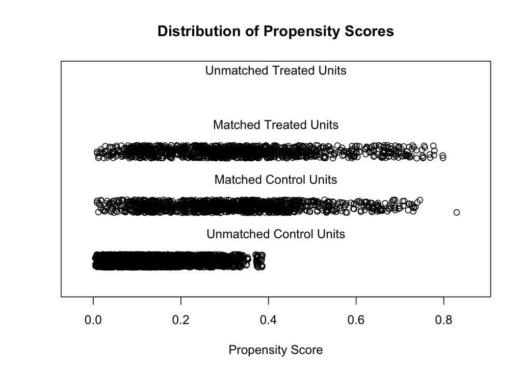

```
## [1] "To identify the units, use first mouse button; to stop, use second."
```

```
## integer(0)
```

```r
plot(matchdat,type="jitter")
```

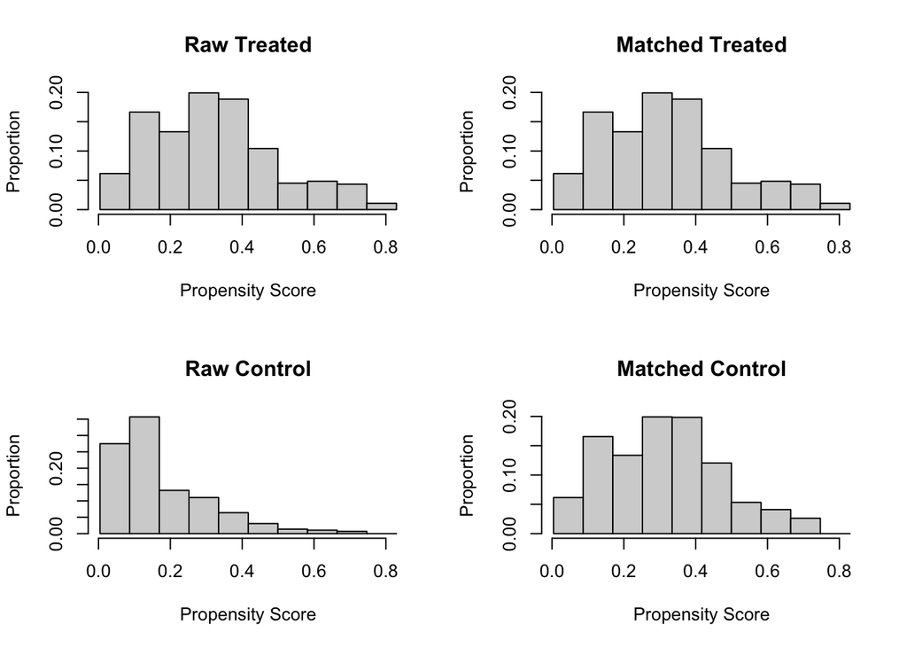

```r
plot(matchdat,type="hist")
```

▸ To do the analysis on the matched cases only, we need to create a new data file with only the matched cases, using: df.match <- match.data(matchdat). Create the Table 1 for this matched data set. What can you conclude?

```r
# To extract the new datafile from the original one:
df.match <- match.data(matchdat)

# Create Table 1:
table1 <- CreateTableOne(vars=c("DISTR.1","BLACK", "NBHISP", "GRADE",
                      "SLFHLTH", "SLFWGHT", "WORKHARD", "GOODQUAL",
                          "PHYSFIT", "PROUD", "LIKESLF", "ACCEPTED",
                      "FEELLOVD"), strata="DIET", data=df.match,
                        test=FALSE)
print(table1, smd=TRUE)
```

```
##                       Stratified by DIET
##                        0           1           SMD
##   n                    1220        1220
##   DISTR.1 (mean (SD))  0.71 (0.45) 0.71 (0.45)  0.007
##   BLACK (mean (SD))    0.18 (0.38) 0.17 (0.38)  0.004
##   NBHISP (mean (SD))   0.16 (0.36) 0.15 (0.36)  0.007
##   GRADE (mean (SD))    9.37 (1.35) 9.37 (1.34)  0.002
##   SLFHLTH (mean (SD))  2.36 (0.95) 2.35 (0.91)  0.011
##   SLFWGHT (mean (SD))  3.82 (0.69) 3.84 (0.70)  0.033
##   WORKHARD (mean (SD)) 2.07 (0.86) 2.05 (0.85)  0.022
##   GOODQUAL (mean (SD)) 1.81 (0.65) 1.84 (0.71)  0.049
##   PHYSFIT (mean (SD))  2.53 (0.97) 2.53 (0.93)  0.007
##   PROUD (mean (SD))    1.85 (0.77) 1.86 (0.79)  0.011
##   LIKESLF (mean (SD))  2.46 (1.05) 2.52 (1.06)  0.057
##   ACCEPTED (mean (SD)) 2.33 (1.03) 2.35 (1.06)  0.023
##   FEELLOVD (mean (SD)) 1.92 (0.87) 1.93 (0.90)  0.010
```

▸ Subsequently, investigate with a t-test whether the means on the outcome variable DISTR.2 differ among the matched cases.

```r
# Do a t-test on the matched data file:
t.test2 <- t.test(DISTR.2 ~ DIET, df.match)
t.test2
```

```
##
##  Welch Two Sample t-test
##
## data:  DISTR.2 by DIET
## t = 1.1383, df = 2438, p-value = 0.2551
## alternative hypothesis: true difference in means between group 0 and group 1 is not equal to 0
## 95 percent confidence interval:
##  -0.01603559  0.06041264
## sample estimates:
## mean in group 0 mean in group 1
##       0.7253279       0.7031393
```

```r
# Note the means per group are included at the bottom.
# We can also compute the mean difference, using:
t.test2$estimate[[2]] - t.test2$estimate[[1]]
```

```
## [1] -0.02218852
```

▸ Compare this result to the mean comparison you did at the start; explain why the mean differences that you have just determined is an estimate of the ACE1 rather than of the ACE.

### 4.3 Metod 5: IPW

▸ Compute the ACE using this IPW (see Equation (20) in S&K).

```r
Y <- df$DISTR.2
X <- df$DIET
mu1hat <- sum( X*Y/ps ) / sum(X/ps)
mu0hat <- sum( (1-X)*Y/(1-ps) ) / sum((1-X)/(1-ps))
mu1hat - mu0hat
```

```
## [1] -0.005064163
```

```r
# For those who are interested, a more sophisticated
# way of getting the ACE using IPW is given below; it is based on
# using the package survey in R. """This makes more sense?! """ :)
library(survey)
library(tableone)

weight <- ifelse(df$DIET==1, 1/(df$ps), 1 / (1-df$ps))
weighteddata <- svydesign(ids = ~ 1, data =df, weights = ~ weight)
weightedtable <- svyCreateTableOne(vars=c("DISTR.1","BLACK", "NBHISP", "GRADE",
                      "SLFHLTH", "SLFWGHT", "WORKHARD", "GOODQUAL",
                          "PHYSFIT", "PROUD", "LIKESLF", "ACCEPTED",
                      "FEELLOVD"), strata = "DIET",
                      data = weighteddata, test = FALSE)

#print(weightedtable, smd=TRUE) ### print doesn't work "non-numeric argument ~" WHY???

# fit a linear model
msm <- svyglm(DISTR.2 ~ DIET, design = weighteddata)
summary(msm)
```

```
##
## Call:
## svyglm(formula = DISTR.2 ~ DIET, design = weighteddata)
##
## Survey design:
## svydesign(ids = ~1, data = df, weights = ~weight)
##
## Coefficients:
##              Estimate Std. Error t value Pr(>|t|)
## (Intercept)  0.660949   0.007029  94.032   <2e-16 ***
## DIET        -0.005064   0.030394  -0.167    0.868
## ---
## Signif. codes:  0 '***' 0.001 '**' 0.01 '*' 0.05 '.' 0.1 ' ' 1
##
## (Dispersion parameter for gaussian family taken to be 0.2397251)
##
## Number of Fisher Scoring iterations: 2
```

```r
confint(msm)
```

```
##                   2.5 %     97.5 %
## (Intercept)  0.64716947 0.67472808
## DIET        -0.06464777 0.05451944
```

### 4.4 Method 6: Subclassification

▸ Begin with creating five strata based on the propensity scores (for instance, use the function cut() in R); each stratum should contain 20% of the (total number of) observations.

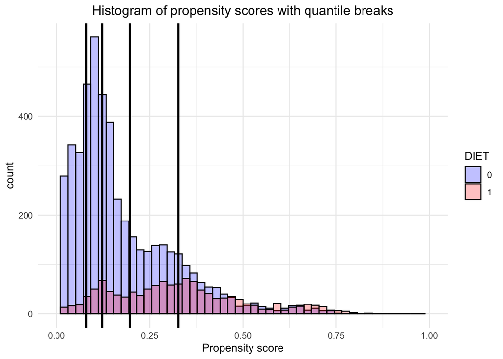

```r
df$stratum <- cut(df$ps,
                    breaks=c(quantile(df$ps, probs=seq(0,1,0.2))),
                    labels=seq(1:5),
                    include.lowest=TRUE)

# We can also make a plot of these quantiles; this is based on
# using the same histogram we had before, now adding vertical
# lines for where the breaks of the strata are.
br <- c(quantile(df$ps, probs=seq(0,1,0.2)))
e <-as.numeric(br[c(2,3,4,5)])

df %>%
  ggplot(aes(x=ps, fill=factor(DIET))) +
  geom_histogram(color="black", position="identity", bins=50) +
  scale_fill_manual(values=c(rgb(0,0,1,1/4), rgb(1,0,0,1/4)), name="DIET") +
  labs(title="Histogram of propensity scores with quantile breaks", x = "Propensity score") + xlim(0,1) + theme(plot.title = element_text(hjust = 0.5))+
  geom_vline(aes(xintercept = br[2]), size=1)+
  geom_vline(aes(xintercept = br[3]), size=1)+
  geom_vline(aes(xintercept = br[4]), size=1)+
  geom_vline(aes(xintercept = br[5]), size=1)+
  theme_minimal() + theme(plot.title = element_text(hjust = 0.5))
```

▸ Next, compute the ACE in each stratum, taking the mean difference.

```r
# We perform a t-test in each stratum.

results <- matrix(NA, 5,1)
for (quantiles in 1:5) {
  t.test3 <- t.test(DISTR.2 ~ DIET, data = df[which(df$stratum==quantiles),])
  print(t.test3)
  # Difference in means:
  results[quantiles,1] <- t.test3$estimate[[2]] - t.test3$estimate[[1]]
}
```

```
##
##  Welch Two Sample t-test
##
## data:  DISTR.2 by DIET
## t = -0.64615, df = 64.606, p-value = 0.5205
## alternative hypothesis: true difference in means between group 0 and group 1 is not equal to 0
## 95 percent confidence interval:
##  -0.18089062  0.09246131
## sample estimates:
## mean in group 0 mean in group 1
##       0.5672608       0.6114754
##
##
##  Welch Two Sample t-test
##
## data:  DISTR.2 by DIET
## t = -0.066853, df = 117.53, p-value = 0.9468
## alternative hypothesis: true difference in means between group 0 and group 1 is not equal to 0
## 95 percent confidence interval:
##  -0.10149097  0.09486247
## sample estimates:
## mean in group 0 mean in group 1
##       0.5812489       0.5845631
##
##
##  Welch Two Sample t-test
##
## data:  DISTR.2 by DIET
## t = -1.7668, df = 197.78, p-value = 0.0788
## alternative hypothesis: true difference in means between group 0 and group 1 is not equal to 0
## 95 percent confidence interval:
##  -0.15963403  0.00876165
## sample estimates:
## mean in group 0 mean in group 1
##       0.6600766       0.7355128
##
##
##  Welch Two Sample t-test
##
## data:  DISTR.2 by DIET
## t = 2.0353, df = 665.97, p-value = 0.04222
## alternative hypothesis: true difference in means between group 0 and group 1 is not equal to 0
## 95 percent confidence interval:
##  0.001992495 0.111069883
## sample estimates:
## mean in group 0 mean in group 1
##       0.6792056       0.6226744
##
##
##  Welch Two Sample t-test
##
## data:  DISTR.2 by DIET
## t = 1.2039, df = 1174.8, p-value = 0.2289
## alternative hypothesis: true difference in means between group 0 and group 1 is not equal to 0
## 95 percent confidence interval:
##  -0.02164432  0.09038353
## sample estimates:
## mean in group 0 mean in group 1
##       0.8102329       0.7758633
```

▸ Subsequently, you can compute the overall ACE by taking the average of the stratum-specific ACE’s (weighted by the stratum size).

```r
# Note that since our five strata are based on quantiles, the sample
# size of each stratum will be the same (i.e. 1/5th of the total sample size)
# such that each stratum-specific ACE adds equally to the total.
# Note that this also means that our ACE estimate will differ somewhat
# from the ACE estimate reported in Table 6 by Schafer and Kang, as they
# had further divided the fifth stratum.
# To get the ACE, we simply take the mean of the stratum-specific ACEs:
mean(results[,1])
```

```
## [1] 0.006412859
```